# Exploring natural disaster impact on american health and economics with NOAA Storm Database

## Synopsis

Natural disasters and other severe weather events lead to both immediate and long term detrimental issue in population health and economics across communities in the US. In order to formulate protocols to minimize the effect of these events, examination of storm databases (NOAA) are used for official decision making. This report takes recorded storm events 1950-2011 collected by the NOAA across the US and quantifies impact on population health (via fatalities and injuries) and economics (via property and crop damage cost). On a national scale, events like tornadoes and water related events played the largest impact on population health, with water related events and tornadoes playing the largest impact on economics. When comparing event impact across regions, it appeared that the top 10 national events did not equally impact all regions.

## Data Processing

1. Loading necessary packages

```r
library(dplyr)
library(reshape2)
library(ggplot2)
library(knitr)
library(kableExtra)
```

2. Import Storm Data into R

```r
# download bzip2 file from link
URL <- "https://d396qusza40orc.cloudfront.net/repdata%2Fdata%2FStormData.csv.bz2"
download.file(URL, destfile="./repdata_data_StormData.csv.bz2", method="curl")
# unzip and read csv file into R
StormData <-read.csv(bzfile("repdata_data_StormData.csv.bz2"), header=TRUE, sep=",")
```

3. Formatting and Cleaning StormData for analysis

```r
# extract only needed variables
StormData <- StormData[,c(7,8,23:28)]
# fix Proprety exponent variable to proper numericals
StormData$PROPDMGEXP <- as.character(StormData$PROPDMGEXP)
StormData$PROPDMGEXP <- toupper(StormData$PROPDMGEXP)
StormData$PROPDMGEXP[StormData$PROPDMGEXP=="B"] <- "9"
StormData$PROPDMGEXP[StormData$PROPDMGEXP=="H"] <- "2"
StormData$PROPDMGEXP[StormData$PROPDMGEXP=="K"] <- "3"
StormData$PROPDMGEXP[StormData$PROPDMGEXP=="M"] <- "6"
StormData$PROPDMGEXP[StormData$PROPDMGEXP=="-"] <- "0"
StormData$PROPDMGEXP[StormData$PROPDMGEXP=="?"] <- "0"
StormData$PROPDMGEXP[StormData$PROPDMGEXP=="+"] <- "0"
StormData$PROPDMGEXP[StormData$PROPDMGEXP==""] <- "1"
# fix Crop exponent variable to proper numerical
StormData$CROPDMGEXP <- as.character(StormData$CROPDMGEXP)
StormData$CROPDMGEXP <- toupper(StormData$CROPDMGEXP)
StormData$CROPDMGEXP[StormData$CROPDMGEXP=="B"] <- "9"
StormData$CROPDMGEXP[StormData$CROPDMGEXP=="K"] <- "3"
StormData$CROPDMGEXP[StormData$CROPDMGEXP=="M"] <- "6"
StormData$CROPDMGEXP[StormData$CROPDMGEXP=="?"] <- "0"
StormData$CROPDMGEXP[StormData$CROPDMGEXP==""] <- "1"
# calculate Property and crop dollar deficite based on exponent variables
StormData$PropCost <- StormData$PROPDMG * 10^as.numeric(StormData$PROPDMGEXP)
StormData$CropCost <- StormData$CROPDMG * 10^as.numeric(StormData$CROPDMGEXP)
# categorize states by region based on US census parameters (NorthEast, West, South, MidWest, Other Territories)
StormData$STATE <- as.character(StormData$STATE)
StormData$Region[StormData$STATE %in% c("CT", "ME", "MA", "NH", "RI", "VT", "NJ", "NY", "PA")] <- "NorthEast"
StormData$Region[StormData$STATE %in% c("AZ", "CO", "ID", "MT", "NV", "NM", "UT", "WY", "AK", "CA", "HI", "OR", "WA")] <- "West"
StormData$Region[StormData$STATE %in% c("IL", "IN", "MI", "OH", "WI","IA", "KS", "MN", "MO", "NE", "ND", "SD")] <- "MidWest"
StormData$Region[StormData$STATE %in% c("DE", "FL", "GA", "MD", "NC", "SC", "VA", "DC", "WV", "AL", "KY", "MS", "TN", "AR", "LA", "OK", "TX")] <- "South"
StormData$Region[StormData$STATE %in% c("AM", "AN", "AS", "GM", "GU", "LC", "LE", "LH", "LM", "LO", "LS", "MH", "PH", "PK", "PM", "PR", "PZ", "SL", "ST", "VI", "XX")] <- "Other Territories"
StormData$Region <- factor(StormData$Region)
```

4. Determine which events were detrimental to population health on a nation-wide scale

```r
# extract necessary variables
HumanImpact <- StormData[,c(1:4)]
# calculate fatality and injury sum by EVTYPE
HumanImpact <- HumanImpact %>% group_by(EVTYPE) %>% summarize(Fatalities=sum(FATALITIES), Injuries=sum(INJURIES))
# order values from highest to lowest and only keep the top 10
HumanImpact <- HumanImpact[order(-HumanImpact$Fatalities),]
HumanImpact <- HumanImpact[1:10,]
```

**Top 10 events to affect american population health:**

| EVTYPE | Fatalities | Injuries |
| --- | --- | --- |
| TORNADO | 5633 | 91346 |
| EXCESSIVE HEAT | 1903 | 6525 |
| FLASH FLOOD | 978 | 1777 |
| HEAT | 937 | 2100 |
| LIGHTNING | 816 | 5230 |
| TSTM WIND | 504 | 6957 |
| FLOOD | 470 | 6789 |
| RIP CURRENT | 368 | 232 |
| HIGH WIND | 248 | 1137 |
| AVALANCHE | 224 | 170 |

5. Determine which events had the greatest impact on american economics nationwide

```r
# extract necessary variables
EcoImpact <- StormData[,c(1:2,9:10)]
# calculate property and crop sum by EVTYPE
EcoImpact <- EcoImpact %>% group_by(EVTYPE) %>% summarize(Property=sum(PropCost), Crops=sum(CropCost))
# order values from highest to lower and only keep top 10
EcoImpact <- EcoImpact[order(-EcoImpact$Property),]
EcoImpact <- EcoImpact[1:10,]
```

**Top 10 events to affect american economics:**

| EVTYPE | Property | Crops |
| --- | --- | --- |
| FLOOD | 144657709870 | 5661968450 |
| HURRICANE/TYPHOON | 69305840000 | 2607872800 |
| TORNADO | 56947380704 | 414953270 |
| STORM SURGE | 43323536000 | 5000 |
| FLASH FLOOD | 16822675842 | 1421317100 |
| HAIL | 15735268026 | 3025954500 |
| HURRICANE | 11868319010 | 2741910000 |
| TROPICAL STORM | 7703890550 | 678346000 |
| WINTER STORM | 6688497251 | 26944000 |
| HIGH WIND | 5270046295 | 638571300 |

6. Regional impact on population health and economics

*Since these events are greatly influenced by vast american geography, found it beneficial to examine which regions of the country contributed most to the top 10 events to impact both american economics and population health in the nation wide scale.*

- Examine how health impact differed amoung american regions

```r
# extract necessary variables
HumanImpact1 <- StormData[,c(1:4,11)]
# calculate fatalities and injuries by Region and EVTYPE
HumanImpact1 <- HumanImpact1 %>% group_by(Region, EVTYPE) %>% summarize(Fatalities=sum(FATALITIES), Injuries=sum(INJURIES))
# subset dataframe by region and order each highest to lowest based on fatalities/injurues
healthNE <- subset(HumanImpact1, Region=="NorthEast")
healthNE <- healthNE[order(-healthNE$Fatalities),]
healthW <- subset(HumanImpact1, Region=="West")
healthW <- healthW[order(-healthW$Fatalities),]
healthMW <- subset(HumanImpact1, Region=="MidWest")
healthMW <- healthMW[order(-healthMW$Fatalities),]
healthS <- subset(HumanImpact1, Region=="South")
healthS <- healthS[order(-healthS$Fatalities),]
healthO <- subset(HumanImpact1, Region=="Other Territories")
healthO <- healthO[order(-healthO$Fatalities),]
# save top 10 events from each region into one table
hRegion <- cbind(healthNE[1:10,1:2],healthS[1:10,1:2],healthMW[1:10,1:2],healthW[1:10,1:2],healthO[1:10,1:2])
```

- Examine how economical impact differed amoung regions

```r
# extract necessary variables
EcoImpact1 <- StormData[,c(1:2,9:11)]
# calculate Property and Crop amount damage by Region and EVTYPE
EcoImpact1 <- EcoImpact1 %>% group_by(Region, EVTYPE) %>% summarize(Property=sum(PropCost), Crops=sum(CropCost))
# subset dataframe by region and order each highest to lowest based on Property/Crop cost damage
ecoNE <- subset(EcoImpact1, Region=="NorthEast")
ecoNE <- ecoNE[order(-ecoNE$Property),]
ecoW <- subset(EcoImpact1, Region=="West")
ecoW <- ecoW[order(-ecoW$Property),]
ecoMW <- subset(EcoImpact1, Region=="MidWest")
ecoMW <- ecoMW[order(-ecoMW$Property),]
ecoS <- subset(EcoImpact1, Region=="South")
ecoS <- ecoS[order(-ecoS$Property),]
ecoO <- subset(EcoImpact1, Region=="Other Territories")
ecoS <- ecoS[order(-ecoS$Property),]
# save top 10 events from each region into one table
eRegion <- cbind(ecoNE[1:10,1:2],ecoS[1:10,1:2],ecoMW[1:10,1:2],ecoW[1:10,1:2],ecoO[1:10,1:2])
```

**regional impact tables displayed in next section** ________________________________________________________________________________

## Results

1. Across the United States, which types of events are most harmful with respect to population health?

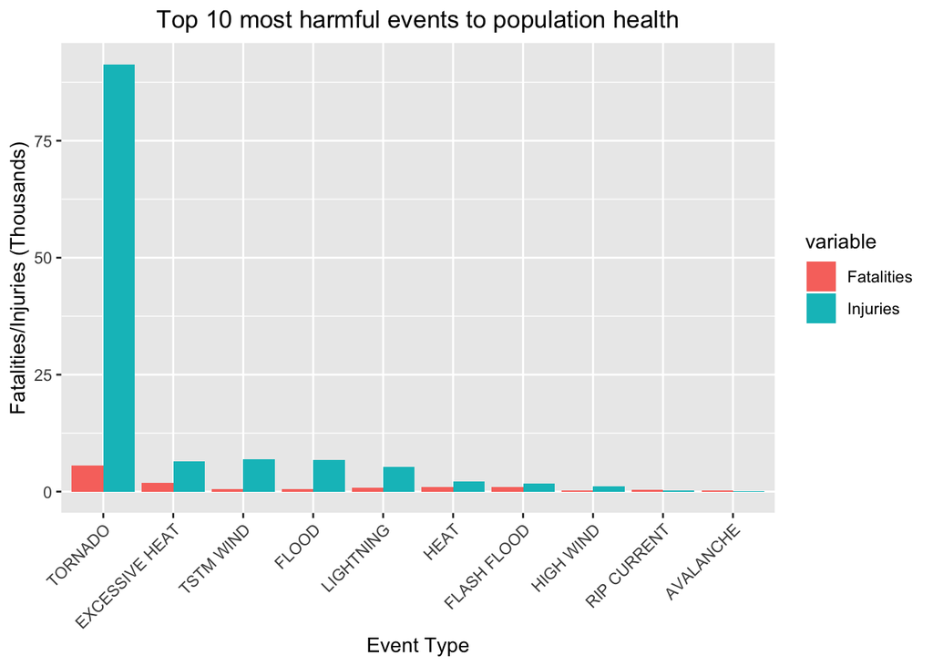

```r
## reshape dataframe so fatality and injury is in one variable column as factor
HumanImpact <- melt(HumanImpact, id.var="EVTYPE", measure.vars=c("Fatalities", "Injuries"))
## create plot
h <- ggplot(HumanImpact, aes(x=reorder(EVTYPE, -value), y=value/1e3))
hChart <- h + geom_col(aes(fill=variable), position="dodge") + labs(x="Event Type", y="Fatalities/Injuries (Thousands)", title="Top 10 most harmful events to population health") + theme(axis.text.x=element_text(angle=45, hjust=1), plot.title=element_text(hjust=0.5))
print(hChart)
```

*This chart highlights the top 10 events that cause the highest fatalities and injuries across the country. Particularly, tornadoes demonstrate a significant impact on population health by causing a large amount of injuries.*

2. Across the United States, which types of events have the greatest economic consequences?

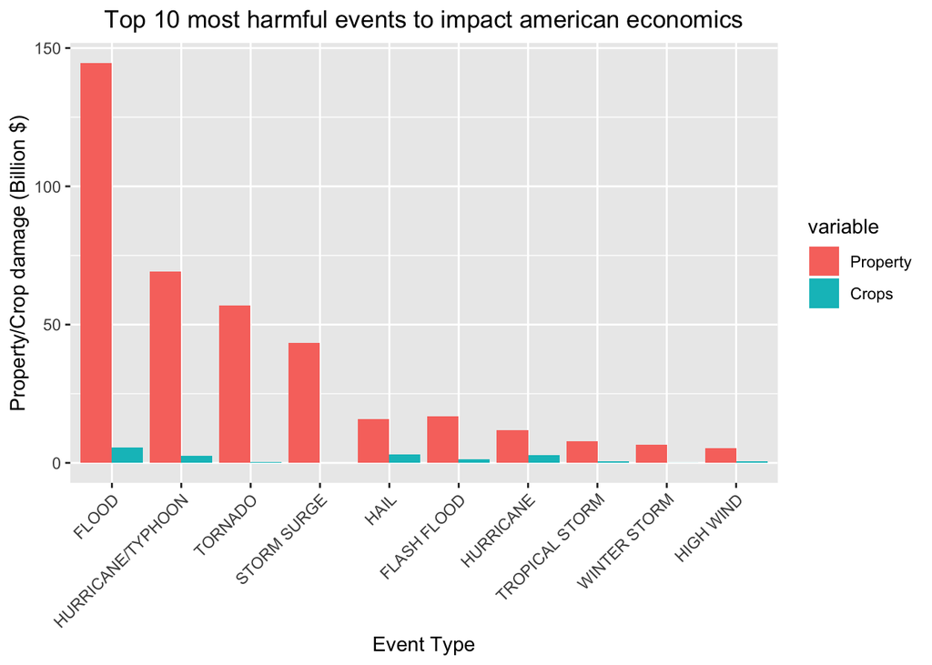

```r
## reshape the data frame so property and crop is in one variable as factor
EcoImpact <- melt(EcoImpact, id.var="EVTYPE", measure.vars=c("Property", "Crops"))
## create plot
e <- ggplot(EcoImpact, aes(x=reorder(EVTYPE, -value), y=value/1e9))
eChart <- e + geom_col(aes(fill=variable), position="dodge") + labs(x="Event Type", y="Property/Crop damage (Billion $)", title="Top 10 most harmful events to impact american economics") + theme(axis.text.x=element_text(angle=45, hjust=1), plot.title=element_text(hjust=0.5))
print(eChart)
```

*This chart highlights the top 10 events that cause the highest property and crop damage across the country. Particularly, floods demonstrate a significant impact on economics by causing a large amount of property damage.*

3. Extra: How does regional data collection affect final numbers on population health and economic impact?

**Top 10 events that impact population health according to region:**

| Region | EVTYPE | Region1 | EVTYPE1 | Region2 | EVTYPE2 | Region3 | EVTYPE3 | Region4 | EVTYPE4 |
| --- | --- | --- | --- | --- | --- | --- | --- | --- | --- |
| NorthEast | EXCESSIVE HEAT | South | TORNADO | MidWest | TORNADO | West | AVALANCHE | Other Territories | FLASH FLOOD |
| NorthEast | TORNADO | South | EXCESSIVE HEAT | MidWest | HEAT | West | EXCESSIVE HEAT | Other Territories | HEAVY RAIN |
| NorthEast | HEAT WAVE | South | FLASH FLOOD | MidWest | EXCESSIVE HEAT | West | FLASH FLOOD | Other Territories | TSUNAMI |
| NorthEast | FLASH FLOOD | South | LIGHTNING | MidWest | FLASH FLOOD | West | LIGHTNING | Other Territories | RIP CURRENTS |
| NorthEast | FLOOD | South | RIP CURRENT | MidWest | TSTM WIND | West | HIGH WIND | Other Territories | RIP CURRENT |
| NorthEast | TSTM WIND | South | TSTM WIND | MidWest | LIGHTNING | West | WINTER STORM | Other Territories | HURRICANE |
| NorthEast | LIGHTNING | South | FLOOD | MidWest | FLOOD | West | HIGH SURF | Other Territories | HIGH SURF |
| NorthEast | HIGH WIND | South | HEAT | MidWest | EXTREME HEAT | West | HEAVY SNOW | Other Territories | MARINE STRONG WIND |
| NorthEast | RIP CURRENT | South | RIP CURRENTS | MidWest | EXTREME COLD/WIND CHILL | West | HEAT | Other Territories | HEAVY SURF/HIGH SURF |
| NorthEast | UNSEASONABLY WARM AND DRY | South | EXTREME COLD | MidWest | COLD/WIND CHILL | West | FLOOD | Other Territories | LIGHTNING |

*When comparing top 10 events to impact population health by region, it indicated that the fatality and injury numbers for tornadoes come from primarily the south and midwest part of the country. Each region of the country contributes to the other top 10 events in varying degrees.*

**Top 10 events that american economics according to region:**

| Region | EVTYPE | Region1 | EVTYPE1 | Region2 | EVTYPE2 | Region3 | EVTYPE3 | Region4 | EVTYPE4 |
| --- | --- | --- | --- | --- | --- | --- | --- | --- | --- |
| NorthEast | FLOOD | South | HURRICANE/TYPHOON | MidWest | TORNADO | West | FLOOD | Other Territories | HIGH SURF ADVISORY |
| NorthEast | FLASH FLOOD | South | STORM SURGE | MidWest | FLOOD | West | HAIL | Other Territories | BRUSH FIRE |
| NorthEast | TORNADO | South | TORNADO | MidWest | HAIL | West | WILDFIRE | Other Territories | COASTAL FLOOD |
| NorthEast | ICE STORM | South | FLOOD | MidWest | FLASH FLOOD | West | WILD/FOREST FIRE | Other Territories | Coastal Flooding |
| NorthEast | TSTM WIND | South | HURRICANE | MidWest | RIVER FLOOD | West | FLASH FLOOD | Other Territories | COASTAL FLOODING |
| NorthEast | HEAVY SNOW | South | TROPICAL STORM | MidWest | TSTM WIND | West | TORNADO | Other Territories | DROUGHT |
| NorthEast | HIGH WIND | South | FLASH FLOOD | MidWest | WINTER STORM | West | WILD FIRES | Other Territories | DRY SPELL |
| NorthEast | THUNDERSTORM WINDS | South | WINTER STORM | MidWest | THUNDERSTORM WIND | West | HEAVY RAIN | Other Territories | DUST STORM |
| NorthEast | WINTER STORM | South | STORM SURGE/TIDE | MidWest | HIGH WIND | West | HIGH WIND | Other Territories | EXTREME HEAT |
| NorthEast | TROPICAL STORM | South | HAIL | MidWest | ICE STORM | West | TSTM WIND | Other Territories | FLASH FLOOD |